# Analiza danych telemetrycznych z symulatora Assetto Corsa Competizione

Na przykładzie danych z wyścigu na torze Brands Hatch pojazdem McLaren 720s GT3 Evo

Karolina Sawicka IAD 102994

## 1. Wprowadzenie i cel projektu

### 1.1. Wprowadzenie

Współczesny sport motorowy oraz zaawansowane symulatory wyścigowe (ang. *simracing*) generują ogromne strumienie danych telemetrycznych o wysokiej częstotliwości próbkowania. Analiza tych danych stanowi kluczowy element optymalizacji osiągów pojazdu oraz wsparcia kierowcy w czasie rzeczywistym. Symulator *Assetto Corsa Competizione* (ACC), charakteryzuje się niezwykle zaawansowanym i certyfikowanym silnikiem fizycznym, który z wysoką wiernością odwzorowuje dynamikę pojazdów klasy GT3 i GT4, pracę zawieszenia, aerodynamikę oraz zjawiska utraty przyczepności opon.

Tradycyjne metody analizy telemetrii opierają się na manualnym przeglądaniu wykresów przez inżyniera wyścigowego w poszukiwaniu anomalii lub błędów kierowcy. Podejście to jest jednak ograniczone czasowo i podatne na błędy ludzkie. Zastosowanie technik eksploracji danych (ang. *data mining*) oraz algorytmów uczenia maszynowego otwiera nowe możliwości w zakresie automatycznej detekcji stanów dynamicznych pojazdu na podstawie sygnałów płynących bezpośrednio z czujników (pozycja pedałów, kąt obrotu kierownicy, prędkości obrotowe kół, siły G).

### 1.2. Cel projektu

Głównym celem niniejszego projektu jest zbudowanie *machine learning pipeline* w oparciu o **`tidymodels`** w środowisku R, służącego do automatycznej klasyfikacji i predykcji momentów aktywacji systemów asystujących kierowcy – układu zapobiegającego blokowaniu kół podczas hamowania (**ABS**) oraz systemu kontroli trakcji (**TC**) – na podstawie surowych danych telemetrycznych z symulatora *Assetto Corsa Competizione*.

Z inżynieryjnego punktu widzenia, celem jest stworzenie klasyfikatorów zdolnych do rozpoznania, na podstawie sygnałów z czujników dynamicznych oraz akcji kierowcy, że pojazd osiąga fizyczną granicę przyczepności wzdłużnej i bocznej, co skutkuje automatyczną interwencją systemów pokładowych.

## 2. Charakterystyka danych telemetrycznych z Assetto Corsa Competizione

Zbiór danych pochodzi z certyfikowanego symulatora wyścigowego *Assetto Corsa Competizione* i reprezentuje surowy zapis parametrów fizycznych pojazdu klasy GT3 podczas pełnego dystansu wyścigowego (44 okrążenia).

### Profil techniczny zbioru:

- **Liczba rekordów:** $> 800\ 000$ wierszy.
- **Częstotliwość próbkowania:** 200 Hz (zapis klatkowy dokładnie co 5 ms ($0.005$ s), co pozwala na bezbłędne uchwycenie mikrozmian w dynamice zawieszenia i opon.
- **Pochodzenie:** Konwersja surowych logów binarnych formatu `.id` z profesjonalnego oprogramowania inżynierii wyścigowej *MoTeC i2 Pro* do ustrukturyzowanego formatu tekstowego `.csv`.

Przechodząc do charakterystyki danych, chciałabym zwrócić uwagę na kluczowy fakt metodologiczny: **nasz zbiór to de facto szereg czasowy o bardzo wysokiej częstotliwości próbkowania, wynoszącej aż 200 Hz**. Oznacza to, że system rejestruje nowy wiersz danych co 5 milisekund.

Taka specyfika niesie ze sobą konkretne wyzwania i zjawiska statystyczne. Przede wszystkim mamy tu do czynienia z **ekstremalnie silną autokorelacją**. Dwa sąsiadujące wiersze oddalone o 5 ms są do siebie matematycznie bardzo podobne, ponieważ fizyka pojazdu nie jest w stanie zmienić swoich parametrów w mgnieniu oka.

Dla celów modelowania eksploracyjnego, dostępne zmienne (cechy predykcyjne) podzielono na cztery logiczne podgrupy taksonomiczne:

1. **Sygnały sterujące kierowcy (Inputs):** Zmienne opisujące bezpośrednie interakcje człowieka z maszyna (`THROTTLE`, `BRAKE`, `CLUTCH`, `STEERANGLE`).
2. **Kinematyka i dynamika pojazdu (State):** Prędkość globalna, aktualny bieg oraz składowe wektora przyspieszenia (`SPEED`, `GEAR`, `G_LAT`, `G_LON`, `RPMS`).
3. **Systemy asystujące (Control):** Zmienne informujące o ingerencji algorytmów pokładowych pojazdu (`TC`, `ABS`).
4. **Termodynamika i mechanika kontaktu (Boundary conditions):** Parametry pracy zawieszenia, ciśnienia i temperatury opon oraz tarcz hamulcowych (`SUS_TRAVEL_*`, `BRAKE_TEMP_*`, `TYRE_PRESS_*`, `TYRE_TAIR_*`, `WHEEL_SPEED_*`, `BUMPSTOP_*`).

Poniższa tabela przedstawia szczegółowy słownik pojęciowy oraz strukturę analizowanych cech.

| **Nazwa zmiennej (kolumna)** | **Jednostka** | **Opis funkcjonalny / Znaczenie fizyczne** |
| --- | --- | --- |
| **Time** | s | Czas ciągły mierzony od początku sesji logowania. |
| **LAP_BEACON** | — | Marker okrążenia; liczba całkowita zapisywana po przekroczeniu linii mety. |
| **SPEED** | m/s | Prędkość pojazdu. |
| **GEAR** | — | Aktualnie załączony bieg (wartości od 0 do 6, gdzie 0 to bieg wsteczny lub luz). |
| **THROTTLE** | % | Pozycja pedału przyspieszenia w zakresie 0–100%. |
| **BRAKE** | % | Siła nacisku na pedał hamulca w zakresie 0–100%. |
| **CLUTCH** | % | Pozycja pedału sprzęgła (wykorzystywana głównie podczas procedury startowej). |
| **RPMS** | 1/min | Prędkość obrotowa wału korbowego silnika. |
| **STEERANGLE** | deg | Kąt obrotu kolumny kierownicy (wartości dodatnie i ujemne określające kierunek skrętu). |
| **G_LAT** | m/s² | Przyspieszenie boczne (lateralne), wynikające ze skrętu pojazdu. |
| **G_LON** | m/s² | Przyspieszenie wzdłużne (wzrost przy przyspieszaniu, spadek przy hamowaniu). |
| **TC** | — | Indeks poziomu mapy kontroli trakcji (aktywność systemu ograniczającego uślizg kół napędowych). |
| **ABS** | — | Indeks poziomu układu zapobiegającego blokowaniu kół podczas hamowania. |
| **SUS_TRAVEL_LF/RF/LR/RR** | mm | Skok ugięcia zawieszenia dla każdego z 4 kół (LF-lewy przód, RF-prawy przód, etc.). |
| **BRAKE_TEMP_LF/RF/LR/RR** | °C | Bieżąca temperatura tarcz hamulcowych. |
| **TYRE_PRESS_LF/RF/LR/RR** | psi | Ciśnienie wewnątrz opony. |
| **TYRE_TAIR_LF/RF/LR/RR** | °C | Temperatura powłoki powietrznej wewnątrz opony. |
| **WHEEL_SPEED_LF/RF/LR/RR** | m/s | Prędkość liniowa obwodu koła (kluczowa do wyznaczania poślizgu mikro- i makroskopowego). |
| **BUMPSTOPUP/DN_RIDE_LF/RF/LR/RR** | mm | Względna pozycja górnego i dolnego ogranicznika skoku zawieszenia. |
| **BUMPSTOP_FORCE_LF/RF/LR/RR** | N | Siła kontaktowa generowana w momencie całkowitego dobicia zawieszenia do odboju. |
| **EN_… (ET, TL, TD, TB)** | — | Wewnętrzne, syntetyczne mapowania silnika i zmienne środowiskowe symulatora. |

## 3. Inżynieria cech i transformacja danych (Czyszczenie i MI)

### 3.1 Wczytanie danych

Pierwotnie danych z pliku .csv nie dało się poprawnie wczytać ze względu na zamieszczonymi dwoma zbiorami w jednym pliku. Usunięto część odpowiadającą identyfikacji okrążenia od części głównej (`Beacon Markers` zostaną wczytane w dalszej części).

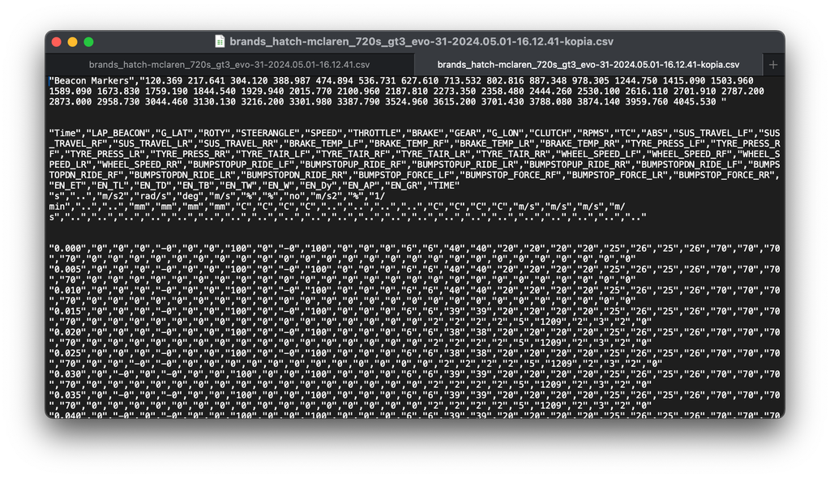

```r
library(tidyverse)
library(infotheo)
library(ggplot2)
library(dplyr)
library(tidyr)
library(tidymodels)
library(themis)
library(rpart)
library(ranger)
library(xgboost)
library(ggplot2)
library(vip)
```

```r
dane <- read.csv("brands_hatch-mclaren_720s_gt3_evo-31-2024.05.01-16.12.41.csv")
#head(dane)
```

Usunięto pierwszy wiersz obserwacji zawierający jednostki poszczególnych zmiennych.

```r
dane <- dane %>% slice(-1)
#head(dane)
```

```r
#str(dane)
```

Wstępny podgląd tabeli pozwala na zweryfikowanie poprawności importu nazw kolumn oraz formatu przechowywanych wartości. Zauważono, że zmienne numeryczne zostały wczytane jako typ tekstowy. Aby umożliwić przeprowadzenie obliczeń statystycznych i modelowania, dokonano automatycznej zamiany przecinków na kropki oraz dokonano konwersji wszystkich odpowiednich kolumn na typ numeryczny. Ponowna weryfikacja potwierdza poprawność wykonanej operacji.

```r
dane <- dane %>%
  mutate(across(
    where(is.character),
    ~ as.numeric(gsub(",", ".", .x))
  ))
#str(dane)
```

### 3.3 Sprawdzenie braków danych, wykrywanie nieaktywnych sensorów

Ważnym elementem przygotowania danych do modelowania statystycznego jest weryfikacja ich kompletności. Wykorzystano funkcję is.na(), aby sprawdzić, czy w logach telemetrii występują przerwy w zapisie.

```r
total_na <- sum(is.na(dane))
print("Liczba brakujących wartości (NA) w zbiorze danych:")
```

```
## [1] "Liczba brakujących wartości (NA) w zbiorze danych:"
```

```r
total_na
```

```
## [1] 0
```

Wynik wynoszący 0 potwierdza, że zbiór jest kompletny, co pozwala na zachowanie ciągłości sygnałów w analizie czasowej i wyklucza konieczność stosowania metod imputacji danych.

W telemetrii wyścigowej wartość 0 może oznaczać zarówno brak aktywności danego systemu (np. pedał hamulca w spoczynku), jak i błąd sensora lub nieaktywny kanał danych. Przeprowadzono analizę procentowego udziału zer dla wszystkich parametrów, co pozwala na wstępne rozpoznanie charakterystyki pracy pojazdu oraz wykrycie zmiennych o niskiej wariancji.

```r
zerowe_wartosci <- dane %>%
  summarise(across(everything(), ~ mean(. == 0, na.rm = TRUE) * 100))

zerowe_wartosci
```

| Time | LAP_BEACON | G_LAT | ROTY | STEERANGLE | SPEED | THROTTLE | BRAKE | GEAR | G_LON | CLUTCH | RPMS | TC | ABS | SUS_TRAVEL_LF | SUS_TRAVEL_RF | SUS_TRAVEL_LR | SUS_TRAVEL_RR | BRAKE_TEMP_LF | BRAKE_TEMP_RF | BRAKE_TEMP_LR | BRAKE_TEMP_RR | TYRE_PRESS_LF | TYRE_PRESS_RF | TYRE_PRESS_LR | TYRE_PRESS_RR | TYRE_TAIR_LF | TYRE_TAIR_RF | TYRE_TAIR_LR | TYRE_TAIR_RR | … |
| --- | --- | --- | --- | --- | --- | --- | --- | --- | --- | --- | --- | --- | --- | --- | --- | --- | --- | --- | --- | --- | --- | --- | --- | --- | --- | --- | --- | --- | --- | --- |
| 0.0001210053 | 100 | 43.54703 | 91.33493 | 11.35949 | 8.821892 | 27.516 | 75.31903 | 7.994337 | 77.20454 | 90.82683 | 7.849373 | 94.47466 | 96.5436 | 0.03751165 | 0.04489297 | 0 | 0 | 0 | 0 | 0 | 0 | 0 | 0 | 0 | 0 | 0 | 0 | 0 | 0 | … |

`LAP_BEACON` ma wartosc 100. To by oznaczało, że cała kolumna `LAP_BEACON` to zera. Podział na okrążenia może nie działać poprawnie. To potwierdza brak wczytanych danych datyczących identyfikacji numeru okrążenia.

```r
# Przekształcenie tabeli na pionową i filtrowanie
puste_parametry <- zerowe_wartosci %>%
  pivot_longer(everything(), names_to = "Parametr", values_to = "Procent_Zer") %>%
  filter(Procent_Zer > 90) %>%
  arrange(desc(Procent_Zer))

# Wyświetlenie listy
print(puste_parametry)
```

```
## # A tibble: 13 × 2
##    Parametr           Procent_Zer
##    <chr>                    <dbl>
##  1 LAP_BEACON               100
##  2 BUMPSTOPDN_RIDE_LR        99.9
##  3 BUMPSTOPDN_RIDE_RR        99.3
##  4 BUMPSTOPDN_RIDE_LF        98.9
##  5 BUMPSTOPUP_RIDE_RF        98.9
##  6 BUMPSTOP_FORCE_LF         97.2
##  7 BUMPSTOP_FORCE_RF         96.9
##  8 BUMPSTOPUP_RIDE_LF        96.8
##  9 ABS                       96.5
## 10 BUMPSTOPDN_RIDE_RF        96.3
## 11 TC                        94.5
## 12 ROTY                      91.3
## 13 CLUTCH                    90.8
```

Analiza wartości zerowych dostarczyła kluczowego wniosku dla celu:

- **`ABS` wynosi zero przez 96.5% czasu jazdy.**
- **`TC` wynosi zero przez 94.5% czasu jazdy.**

To oznacza, że systemy te aktywują się rzadko (odpowiednio przez 3.5% i 5.5% czasu trwania sesji) – tylko wtedy, gdy kierowca dochodzi do limitu przyczepności. Potwierdza to, że nasz problem predykcyjny to **klasyczna klasyfikacja danych niezbalansowanych**.

### 3.4 Standaryzacja jednostek prędkości

W surowej telemetrii prędkość rejestrowana jest w układzie SI ($m/s$). Dla celów analizy inżynierskiej oraz lepszej interpretacji wyników, dokonano konwersji na jednostkę powszechnie stosowaną w sporcie motorowym — kilometry na godzinę ($km/h$). Zmiana nazwy kolumny na `SPEED_MS` pozwala na zachowanie precyzji opisu danych.

```r
dane <- dane %>%
  rename(SPEED_MS = SPEED) %>%

  mutate(SPEED_KMH = SPEED_MS * 3.6, .after = SPEED_MS)
```

W celu poprawy czytelności raportu i wizualizacji, zaimplementowano funkcję `format_racing_time`. Przekształca ona czas wyrażony w sekundach na standardowy format wyścigowy **mm:ss.ms**. Funkcja uwzględnia specyficzne zaokrąglanie milisekund, co jest niezbędne przy porównywaniu czasów okrążeń.

```r
format_racing_time <- function(seconds) {
  mm <- floor(seconds / 60)
  ss <- floor(seconds %% 60)
  ms <- round((seconds - floor(seconds)) * 1000)

  ms[ms == 1000] <- 999

  sprintf("%02d:%02d.%03d", mm, ss, ms)
}
```

Dokonano standaryzacji nazewnictwa głównej osi czasu na `TIME_S` (sekundy sesji). Dodatkowo, wykorzystując wcześniej zdefiniowaną funkcję, utworzono kolumnę `TIME_FMT`.

```r
dane <- dane %>%
  rename(TIME_S = Time) %>%
  mutate(
    TIME_FMT = format_racing_time(TIME_S),
    .after = TIME_S
  )
```

### 3.5 Wstępne czyszczenie

Usunięto dane gdzie pojazd był podczas postoju w boxie/na polach startowych przed startem wyścigu.

```r
# znajdujemy dokładny moment (w sekundach), w którym auto ruszyło po raz pierwszy (prędkość > 2 km/h)
moment_startu <- dane %>%
  filter(SPEED_KMH > 2) %>%
  slice(1) %>%
  pull(TIME_S)

# filtrujemy zbiór danych, zostawiając tylko rekordy od momentu startu w górę
dane <- dane %>%
  filter(TIME_S >= moment_startu)
```

### 3.5. Uzupełnienie danych punktów pomiarowych (Lap Beacons)

Przeprowadzono ręczną rekonstrukcję punktów przecięcia linii mety. Wykorzystano do tego znaczniki czasu ($s$) zidentyfikowane podczas sesji. Dane te posłużą jako klucz do podziału całego zbioru na indywidualne okrążenia, co umożliwi analizę statystyczną powtarzalności kierowcy.

```r
beacons_raw <- "120.369 217.641 304.120 388.987 474.894 536.731 627.610 713.532 802.816 887.348 978.305 1244.750 1415.090 1503.960 1589.090 1673.830 1759.190 1844.540 1929.940 2015.770 2100.960 2187.810 2273.350 2358.480 2444.260 2530.100 2616.110 2701.910 2787.200 2873.000 2958.730 3044.460 3130.130 3216.200 3301.980 3387.790 3524.960 3615.200 3701.430 3788.080 3874.140 3959.760 4045.530"

beacons <- data.frame(
  LAP_BEACON = seq_along(strsplit(beacons_raw, " ")[[1]]),
  Time_lap_s = as.numeric(strsplit(beacons_raw, " ")[[1]])
)
```

### 3.6. Segmentacja sesji na indywidualne okrążenia

Kluczowym wyzwaniem w pracy z surową telemetrią jest podział ciągłego zapisu czasu (`TIME_S`) na logiczne jednostki — okrążenia. Wykorzystano funkcję `findInterval`, która na podstawie zrekonstruowanych wcześniej znaczników (beacons) przypisała każdemu rekordowi numer okrążenia. Jest to fundament pod analizę porównawczą.

```r
dane$TIME_S <- as.numeric(gsub(",", ".", dane$TIME_S))
dane <- dane %>%
  mutate(LAP_BEACON = findInterval(TIME_S, beacons$Time_lap_s) + 1)
```

W celu ułatwienia dostępu do szczegółowych profili prędkości czy hamowania, zbiór danych został rozbity na listę obiektów. Taka struktura pozwala na szybkie wywołanie konkretnego okrążenia bez konieczności każdorazowego filtrowania całej bazy danych, co optymalizuje proces analityczny.

```r
laps_list <- dane %>%
  group_split(LAP_BEACON)

names(laps_list) <- paste0("lap_", sapply(laps_list, function(x) unique(x$LAP_BEACON)))

#head(laps_list$lap_24)
```

### 3.7. Obliczenie rzeczywistych czasów okrążeń

Na podstawie różnicy między maksymalnym a minimalnym czasem wewnątrz każdego segmentu (`LAP_BEACON`), wyliczono precyzyjny czas trwania okrążenia. Wyniki zostały sformatowane do standardu wyścigowego, co pozwala na wstępną ocenę tempa kierowcy na torze Brands Hatch.

```r
lap_times <- dane %>%
  group_by(LAP_BEACON) %>%
  summarise(
    LAP_TIME_S = max(TIME_S) - min(TIME_S)
  ) %>%
  mutate(
    TIME_FMT = format_racing_time
    (LAP_TIME_S)
  ) %>%
  rename(LAP_NUMBER = LAP_BEACON)

print(lap_times)
```

```
## # A tibble: 44 × 3
##    LAP_NUMBER LAP_TIME_S TIME_FMT
##         <dbl>      <dbl> <chr>
##  1          1      109.  01:48.840
##  2          2       97.3 01:37.270
##  3          3       86.5 01:26.470
##  4          4       84.9 01:24.865
##  5          5       85.9 01:25.900
##  6          6       61.8 01:01.835
##  7          7       90.9 01:30.870
##  8          8       85.9 01:25.920
##  9          9       89.3 01:29.280
## 10         10       84.5 01:24.525
## # ℹ 34 more rows
```

### 3.8 Dalsze czyszczenie danych

Zidentyfikowano 2 znacznie dłuższe okrążenia - traktowane jako wartości odstające. Możliwy scenariusz:

- **Okrążenie 12 (04:26.440):** **zjazd do boksów (In-lap) połączony z obsługą serwisową** (wymiana opon, tankowanie, postój). Pojazd poruszał się wtedy z włączonym ogranicznikiem prędkości w alei serwisowej (pit limiter) do 50 km/h, a potem stał w miejscu.
- **Okrążenie 13 (02:50.335):** **okrążenie wyjazdowe (Out-lap)**. Kierowca ruszał z miejsca z boksów, jechał powoli aleją serwisową, a po wyjeździe na tor prawdopodobnie musiał dogrzać nowe, zimne opony, stąd tak wysoki czas.

  Alternatywnie: na okrążeniu 12 lub 13 doszło do potężnego wypadku (dzwon/obrót), po którym kierowca długo wracał na tor i na torze było ograniczenie żółtymi flagami.

```r
dane <- dane %>%
  # usuwamy okrążenia 12 i 13 (Pit stop / Wypadek)
  filter(!(LAP_BEACON %in% c(12, 13)))
```

Ze względu na to, że dynamika pojazdu w boksach oraz procedury obsługi opon wprowadzają szum informacyjny niezwiązany z wyścigową granicą przyczepności, okrążenia te zostały w całości usunięte z bazy treningowej jako obserwacje odstające.

```r
#summary(dane)
```

### 3.9. Definicja zmiennej docelowej i eliminacja wycieku danych

Przed przystąpieniem do analizy istotności cech należy formalnie zdefiniować zmienną objaśnianą `INTERWENCJA` oraz usunąć kolumny, które nie mogą brać udziału w predykcji. Wykluczamy surowe zmienne `ABS` i `TC` (wyciek danych) oraz osie czasu i identyfikatory okrążeń, które nie mają wpływu na fizykę opony.

```r
# --- DEFINICJA TARGETU I OSTATECZNE FILTROWANIE ---
dane_modelowanie <- dane %>%
  # Definicja zmiennej docelowej (klasyfikacja binarna)
  mutate(INTERWENCJA = if_else(ABS > 0 | TC > 0, "Interwencja", "Stabilnie"),
         INTERWENCJA = factor(INTERWENCJA, levels = c("Interwencja", "Stabilnie"))) %>%

  # Filtrowanie prędkości operacyjnej (fizyka opon działa powyżej 20 km/h)
  filter(SPEED_KMH > 20) %>%

  # Usunięcie zmiennych niebędących predyktorami fizycznymi oraz zapobieganie wyciekowi danych
  select(-TIME_S, -TIME_FMT, -LAP_BEACON, -ABS, -TC, -CLUTCH, -SPEED_MS, -TIME, -starts_with("EN_"))

# Sprawdzenie ostatecznego wymiaru ramki danych do modelowania
dim(dane_modelowanie)
```

```
## [1] 703696     42
```

Wymiar ramki (`703696` wierszy, `42` kolumny).

```r
table(dane_modelowanie$INTERWENCJA)
```

```
##
## Interwencja   Stabilnie
##       72293      631403
```

**Rozkład klas:**

- `Interwencja`: 72 293 (ok. **10,27%**)
- `Stabilnie`: 631 403 (ok. **89,73%**)

### 3.10. Selekcja cech przy użyciu Informacji Wzajemnej (Mutual Information)

W celu zidentyfikowania zmiennych o największym potencjale dyskryminacyjnym, zastosowano miarę informacji wzajemnej z pakietu `infotheo`. Metoda ta pozwala wykryć zaawansowane, nieliniowe korelacje, które klasyczny współczynnik korelacji Pearsona mógłby pominąć.

```r
# Dyskretyzacja zmiennych numerycznych (metoda równomiernych przedziałów)
dane_discretized <- infotheo::discretize(dane_modelowanie %>% select(where(is.numeric)))

# Obliczenie wartości Mutual Information względem zmiennej INTERWENCJA
mi_scores <- sapply(dane_discretized, function(col) {
  infotheo::mutinformation(col, dane_modelowanie$INTERWENCJA)
})

# Prezentacja wyników
ranking_cech <- data.frame(
  Predyktor = names(mi_scores),
  Mutual_Information = as.numeric(mi_scores)
) %>%
  arrange(desc(Mutual_Information))

print(ranking_cech)
```

```
##             Predyktor Mutual_Information
## 1       SUS_TRAVEL_LR       8.349767e-02
## 2      WHEEL_SPEED_LR       7.764828e-02
## 3      WHEEL_SPEED_LF       7.660661e-02
## 4      WHEEL_SPEED_RR       7.541852e-02
## 5      WHEEL_SPEED_RF       7.431407e-02
## 6          STEERANGLE       6.678346e-02
## 7           SPEED_KMH       6.672655e-02
## 8                GEAR       6.603526e-02
## 9       BRAKE_TEMP_RF       5.723842e-02
## 10      BRAKE_TEMP_LF       5.639283e-02
## 11              G_LAT       5.270419e-02
## 12      BRAKE_TEMP_RR       5.156548e-02
## 13      BRAKE_TEMP_LR       5.106441e-02
## 14           THROTTLE       4.987288e-02
```

[output cut: 27 more lines]

Na podstawie uzyskanych wyników MI możesz dokonać wstępnej selekcji cech. Zmienne na samym dole rankingu wnoszą tak znikomą ilość informacji, że ich pozostawienie może jedynie wydłużyć czas obliczeń lub powodować szum.

```r
# Wybieramy dokładnie TOP 12 predyktorów o najwyższej wartości MI
zmienne_do_zostawienia <- ranking_cech %>%
  slice_max(order_by = Mutual_Information, n = 12) %>%
  pull(Predyktor)

# Dodajemy zmienną docelową do listy
zmienne_do_zostawienia <- c("INTERWENCJA", zmienne_do_zostawienia)

# Filtrujemy główną ramkę danych
dane_modelowanie <- dane_modelowanie %>%
  select(all_of(zmienne_do_zostawienia))

dim(dane_modelowanie)
```

```
## [1] 703696     13
```

Wymiar nowej ramki (`703696` wierszy, `13` kolumn).

## 4. Eksploracyjna Analiza Danych (EDA) i wizualizacje fizyczne

### 4.1. Wizualizacja kręgu przyczepności Kamma (Friction Circle)

Zgodnie z prawami fizyki dynamiki pojazdów, opona posiada ograniczony limit przyczepności, który musi podzielić pomiędzy siły wzdłużne (hamowanie/przyspieszanie) a siły boczne (skręcanie). Wykres przeciążeń wzdłużnych (`G_LON`) względem bocznych (`G_LAT`) tworzy tzw. *Krąg Kamma*.

Poniższy wykres prezentuje ten stan z podziałem na punkty, w których systemy pokładowe musiały wspomóc kierowcę.

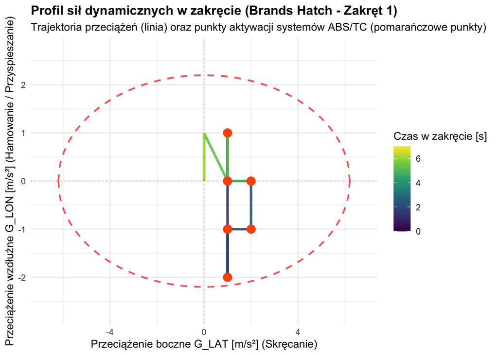

```r
# AUTOMATYCZNE IZOLOWANIE JEDNEGO ZAKRĘTU
# Znajdujemy sekundę, w której kierowca najmocniej wcisnął hamulec na 4. okrążeniu
moment_maks_hamowania <- dane %>%
  filter(LAP_BEACON == 4) %>%
  filter(BRAKE == max(BRAKE)) %>%
  slice(1) %>%
  pull(TIME_S)

# Wycinamy czyste okienko: 1.5 sekundy przed hamowaniem (jazda na prostej)oraz 5.5 sekundy po (wejście w zakręt, apex i wyjście na prostą)
dane_zakret <- dane %>%
  filter(LAP_BEACON == 4,
         TIME_S >= (moment_maks_hamowania - 1.5) &
           TIME_S <= (moment_maks_hamowania + 5.5)) %>%
  mutate(
    INTERWENCJA = if_else(ABS > 0 | TC > 0, "Interwencja", "Stabilnie"),
    INTERWENCJA = factor(INTERWENCJA, levels = c("Interwencja", "Stabilnie")),
    # Tworzymy czas relatywny od początku zakrętu (dla czytelniejszej legendy)
    Czas_Zakretu = TIME_S - min(TIME_S)
  )

# GEOMETRIA ELIPSY PRZYCZEPNOŚCI
# Szerokość (G_LAT) = 6.2, Wysokość (G_LON) = 2.2
max_x <- 6.2
max_y <- 2.2
ellipse_data <- data.frame(
  x = seq(-max_x, max_x, length.out = 200)
) %>%
  mutate(
    y_pos = max_y * sqrt(1 - (x / max_x)^2),
    y_neg = -max_y * sqrt(1 - (x / max_x)^2)
  )

# GENEROWANIEIDEALNEGO WYKRESU
ggplot() +
  # Rysowanie przerywanej linii realnego limitu przyczepności (Elipsa)
  geom_path(data = ellipse_data, aes(x = x, y = y_pos), color = "red", linetype = "dashed", size = 0.8, alpha = 0.7) +
  geom_path(data = ellipse_data, aes(x = x, y = y_neg), color = "red", linetype = "dashed", size = 0.8, alpha = 0.7) +

  # Linie pomocnicze układu współrzędnych (środek fizyczny)
  geom_hline(yintercept = 0, color = "gray80", linetype = "dotted") +
  geom_vline(xintercept = 0, color = "gray80", linetype = "dotted") +

  # PŁYNNA ŚCIEŻKA PRZEJAZDU (Połączenie punktów w idealną trajektorię)
  geom_path(data = dane_zakret, aes(x = G_LAT, y = G_LON, color = Czas_Zakretu), size = 1.2, alpha = 0.9) +

  # DUŻE, WYRAŹNE PUNKTY w miejscach interwencji systemów (np. ABS przy dohamowaniu)
  geom_point(data = dane_zakret %>% filter(INTERWENCJA == "Interwencja"),
             aes(x = G_LAT, y = G_LON), color = "#FF5500", size = 3.5, shape = 19) +

  # Skalowanie osi dopasowane do elipsy (brak pustych przestrzeni)
  coord_cartesian(xlim = c(-max_x - 0.5, max_x + 0.5), ylim = c(-max_y - 0.5, max_y + 0.5)) +

  # Profesjonalna paleta barw (Viridis - cividis lub plasma) pokazuąca sekwencję czasu
  scale_color_viridis_c(option = "viridis") +

  theme_minimal() +
  labs(
    title = "Profil sił dynamicznych w zakręcie (Brands Hatch - Zakręt 1)",
    subtitle = "Trajektoria przeciążeń (linia) oraz punkty aktywacji systemów ABS/TC (pomarańczowe punkty)",
    x = "Przeciążenie boczne G_LAT [m/s²] (Skręcanie)",
    y = "Przeciążenie wzdłużne G_LON [m/s²] (Hamowanie / Przyspieszanie)",
    color = "Czas w zakręcie [s]"
  ) +
  theme(
    plot.title = element_text(face = "bold", size = 13),
    legend.position = "right"
  )
```

### 4.2. Analiza rozkładu ugięcia zawieszenia

W celu szczegółowego zbadania predyktora, który uzyskał najwyższą wartość informacji wzajemnej – `SUS_TRAVEL_LR` (ugięcie zawieszenia koła tylnego lewego) – przygotowano wykres pudełkowy boxplot w rozbiciu na klasę jazdy stabilnej oraz momenty interwencji systemów asystujących.

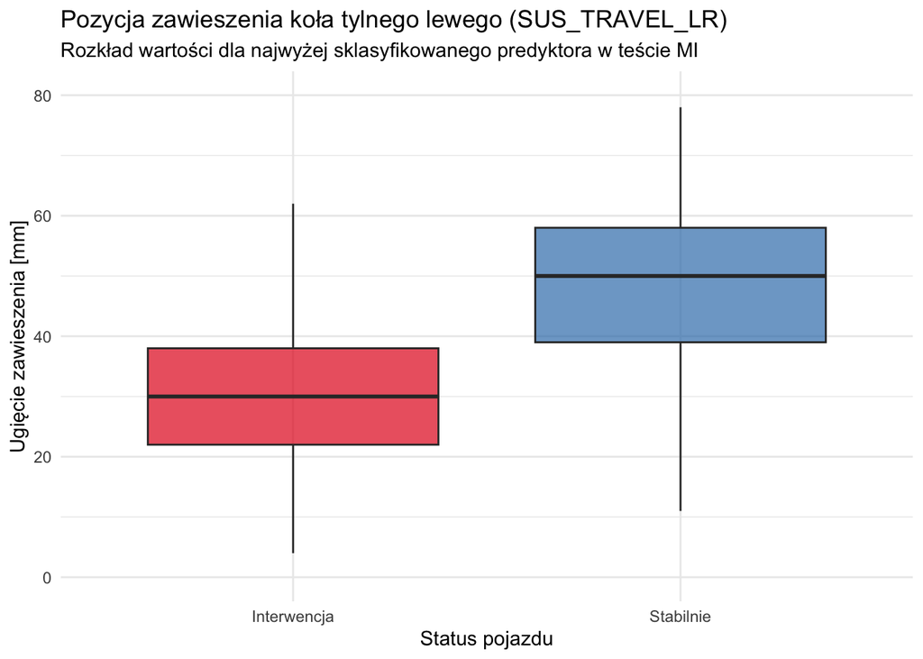

```r
# BOXPLOT (SUS_TRAVEL_LR)
ggplot(dane_modelowanie, aes(x = INTERWENCJA, y = SUS_TRAVEL_LR, fill = INTERWENCJA)) +
  geom_boxplot(outlier.shape = NA, alpha = 0.7) + # ukrywamy outlierzy dla czytelności skali
  coord_cartesian(ylim = c(0, 80)) + # zawężamy oś Y do realnego zakresu pracy pracy zawieszenia
  scale_fill_manual(values = c("Interwencja" = "#E41A1C", "Stabilnie" = "#377EB8")) +
  labs(
    title = "Pozycja zawieszenia koła tylnego lewego (SUS_TRAVEL_LR)",
    subtitle = "Rozkład wartości dla najwyżej sklasyfikowanego predyktora w teście MI",
    x = "Status pojazdu",
    y = "Ugięcie zawieszenia [mm]"
  ) +
  theme_minimal() +
  theme(legend.position = "none")
```

Dla stanu Interwencja rozkład wartości skoku zawieszenia lewego tyłu jest wyraźnie niższy (mediana wynosi dokładnie 30 mm), podczas gdy dla jazdy Stabilnej wartości są wyższe (mediana to 50 mm).

Mniejsza wartość parametru `SUS_TRAVEL` w telemetrii oznacza rozprężenie (uniesienie) amortyzatora, czyli gwałtowne odciążenie danego koła.

Systemy asystujące (głównie ABS na tylnej osi oraz TC) aktywują się najczęściej wtedy, gdy lewe tylne zawieszenie ulega mocnemu rozprężeniu (spadek mediany do poziomu 30 mm). Ma to uzasadnienie w prawach dynamiki. Podczas ekstremalnego dohamowania przed zakrętem 1, który dodatkowo gwałtownie opada w dół, dochodzi do potężnego transferu masy na przednią oś pojazdu. Tylna oś zostaje wtedy ‘odciążona’ (podrywa się do góry). Lekkie, pozbawione docisku pionowego koło natychmiast traci przyczepność wzdłużną i wpada w poślizg, co wymusza natychmiastową i agresywną interwencję systemów pokładowych.”

## 5. Strategia próbkowania i balansowania danych (tidymodels + themis)

Przechodzimy do bezpośredniego przygotowania danych pod budowę 5 modeli. Definiujemy podział na zbiór treningowy i testowy oraz budujemy `recipe`, w którym zaimplementujemy standaryzację oraz balansowanie klas.

Analizowany zbiór danych o wielkości ponad 700 tysięcy obserwacji charakteryzuje się dwiema kluczowymi cechami: silną asymetrią klas (ok. 10% interwencji) oraz ekstremalnie wysoką gęstością próbkowania (200 Hz). Przetwarzanie tak potężnej liczby powtarzalnych wierszy generuje wysoki narzut obliczeniowy, nie wnosząc jednocześnie nowej charakterystyki fizycznej do procesu uczenia.

W celu optymalizacji zasobów maszynowych oraz zapewnienia najwyższego rygoru metodologicznego, wdrożono dwuetapową procedurę przygotowania danych:

1. **Redukcja wolumenu danych metodą ciągłego bloku:** Za pomocą funkcji `slice()` z pełnej ramki danych wyekstrahowano ciągły, chronologiczny fragment obejmujący 150 000 obserwacji. Pominięto początkową fazę sesji (wyjazd z alei serwisowej), izolując czystą jazdę torową. Taka wielkość próby w zupełności zabezpiecza reprezentatywność wszystkich typów zakrętów, drastycznie skracając czas tuningu modeli.
2. **Chronologiczny podział próby (Time Split):** Z uwagi na naturę szeregów czasowych, klasyczny podział losowy doprowadziłby do zjawiska wycieku danych (*temporal data leakage*) przez milisekundowe sąsiedztwo wierszy. Aby temu zapobiec, zastosowano funkcję `initial_time_split()`, która bez dokonywania permutacji (mieszania wierszy) podzieliła wybrany blok w stosunku 80/20. Zbiór treningowy stanowi chronologiczny początek próby, natomiast zbiór testowy to wyłącznie końcowy fragment jazdy. Model zmuszony jest więc do predykcji przyszłych stanów dynamicznych opon, co stanowi realny test jego zdolności do generalizacji.

W końcowym kroku na zbiorze treningowym zaimplementowano procedurę **downsamplingu** (`step_downsample`), sprowadzając proporcję klas `Interwencja` do `Stabilnie` do idealnego stosunku 1:1 na bazie wyłącznie unikalnych, rzeczywistych klatek zarejestrowanych przez system MoTeC.

```r
# 1. OGRANICZENIE ROZMIARU DANYCH (WYCINAMY CIĄGŁY BLOK)
# Zamiast 700 tysięcy wierszy, bierzemy ciągły blok 150 tysięcy wierszy.
# To zredukuje czas trenowania modeli o ok. 80%, zachowując pełną chronologię!
dane_skrócone <- dane_modelowanie %>%
  slice(50000:199999) # Wycinamy bezpieczny środek sesji (omijamy ruszanie z boksów)

# 2. CHRONOLOGICZNY PODZIAŁ SZEREGU CZASOWEGO (BEZ LOSOWANIA)
# Funkcja stawia jedną linię podziału: pierwsze 80% to trening, ostatnie 20% to test.
telemetry_split <- initial_time_split(dane_skrócone, prop = 0.80)

train_data <- training(telemetry_split)
test_data  <- testing(telemetry_split)

# 3. DEFINICJA PRZEPISU PRZETWARZANIA (RECIPE)
telemetry_recipe <- recipe(INTERWENCJA ~ ., data = train_data) %>%
  # Usunięcie ewentualnych zmiennych o zerowej wariancji w wyciętym bloku
  step_zv(all_predictors()) %>%

  # Normalizacja predyktorów numerycznych
  step_normalize(all_numeric_predictors()) %>%

  # Balansowanie klasy większościowej do stosunku 1:1 (Downsampling)
  step_downsample(INTERWENCJA, under_ratio = 1.0)

# Przygotowanie i "wypieczenie" danych
telemetry_prep <- prep(telemetry_recipe)
train_balanced <- bake(telemetry_prep, new_data = NULL)
test_processed  <- bake(telemetry_prep, new_data = test_data)

# Kontrola wyników w konsoli
cat("Wymiary oryginalnego bloku:", dim(dane_skrócone), "\n")
```

```
## Wymiary oryginalnego bloku: 150000 13
```

```r
cat("Liczba wierszy w train_data (przed balansowaniem):", nrow(train_data), "\n")
```

```
## Liczba wierszy w train_data (przed balansowaniem): 120000
```

```r
cat("Liczba wierszy w test_data (czysty, chronologiczny test):", nrow(test_data), "\n\n")
```

```
## Liczba wierszy w test_data (czysty, chronologiczny test): 30000
```

```r
cat("Rozkład klas po zastosowaniu step_downsample w train_balanced:\n")
```

```
## Rozkład klas po zastosowaniu step_downsample w train_balanced:
```

```r
print(table(train_balanced$INTERWENCJA))
```

```
##
## Interwencja   Stabilnie
##       10594       10594
```

### 5.1. Ewaluacja wymiarów danych i efektów balansowania klas

Uruchomienie przygotowanego potoku przetwarzania chronologicznego pozwoliło na uzyskanie następujących, wysoce powtarzalnych struktur danych:

- **Poprawność podziału chronologicznego:** Z wyekstrahowanego bloku 150 000 wierszy, do zbioru treningowego (`train_data`) przypisano dokładnie 120 000 obserwacji, natomiast zbiór testowy (`test_data`) objął 30 000 końcowych wierszy sesji. Gwarantuje to zachowanie rygorystycznej bariery czasowej między fazą nauki a fazą testową.
- **Reprezentatywność podpróby:** W zbiorze treningowym przed procedurą balansowania zarejestrowano 10 594 klatki rzeczywistej interwencji systemów pokładowych, co stanowi 8.83% wyciętego fragmentu. Dowodzi to wysokiej reprezentatywności matematycznej wybranego bloku względem całego pliku telemetrycznego MoTeC (gdzie udział klasy mniejszościowej wynosił 10.27%).
- **Efekt działania procedury step_downsample:** W procesie generowania zbalansowanej ramki treningowej (`train_balanced`), liczebność klasy większościowej `Stabilnie` została zredukowana do poziomu dokładnie 10 594 obserwacji. Wynikowy zbiór treningowy liczy 21 188 wierszy przy zachowaniu idealnej proporcji klas 1:1.

Z inżynieryjnego punktu widzenia, redukcja ta drastycznie optymalizuje narzut obliczeniowy maszyn, eliminując setki tysięcy redundantnych klatek jazdy po prostych odcinkach toru. Jednocześnie baza ponad 10 tysięcy unikalnych i rzeczywistych stanów poślizgu w pełni zabezpiecza potencjał aplikacyjny modeli do nauki nieliniowych granic przyczepności.

## 6. Modelowanie

W celu wyłonienia najbardziej efektywnej architektury predykcyjnej, zaprojektowano i zaimplementowano scentralizowany system komparatywny obejmujący pięć zróżnicowanych klas algorytmów klasyfikacji binarnej. Ewaluacja systemów opiera się na strategii 5-krotnej walidacji krzyżowej generowanej bezpośrednio z surowej próby treningowej z zachowaniem stratyfikacji klas docelowych.

```r
# DEFINICJA STRATEGII WALIDACJI KRZYŻOWEJ (Cross-Validation)
# Folds tworzymy na surowym zbiorze train_data. Strata zapewnia równy rozkład klas w podziałach.
set.seed(42)
cv_folds <- vfold_cv(train_data, v = 5, strata = INTERWENCJA)

# ==========================================
# DEFINICJA SPECYFIKACJI 5 MODELI
# ==========================================

# Model 1: Regresja Logistyczna (Model bazowy - Baseline)
spec_log_reg <- logistic_reg() %>%
  set_engine("glm") %>%
  set_mode("classification")

# Model 2: Drzewo Decyzyjne (CART) - z dostrajaniem złożoności i głębokości
spec_tree <- decision_tree(
  cost_complexity = tune(),
  tree_depth = tune()
) %>%
  set_engine("rpart") %>%
  set_mode("classification")

# Model 3: Las Losowy (Random Forest) - szybki silnik ranger
spec_rf <- rand_forest(
  trees = 100,             # 100 drzew zapewnia idealny kompromis stabilności i czasu
  min_n = tune()
) %>%
  set_engine("ranger", importance = "impurity") %>%
  set_mode("classification")

# Model 4: Gradient Boosting (XGBoost)
spec_xgb <- boost_tree(
  trees = 100,
  tree_depth = tune(),
  learn_rate = tune()
) %>%
  set_engine("xgboost") %>%
  set_mode("classification")

# Model 5: Wielowarstwowa Sieć Neuronowa (MLP)
spec_mlp <- mlp(
  hidden_units = tune(),
  epochs = 50
) %>%
  set_engine("nnet") %>%
  set_mode("classification")

# ==========================================
# BUDOWA WORKFLOWS I SIATEK STROJENIA (Grids)
# ==========================================

# Jako bazę stosujemy kompletny telemetry_recipe z sekcji 5 (zawiera normalizację i downsample)
# UWAGA: tidymodels automatycznie dopilnuje, aby balansowanie klas zachodziło wewnątrz foldów!

# Definiujemy niewielkie siatki wartości parametrów (dla optymalizacji czasu obliczeń)
grid_tree <- grid_regular(cost_complexity(), tree_depth(range = c(3, 10)), levels = 3)
grid_rf   <- grid_regular(min_n(), levels = 3)
grid_xgb  <- grid_regular(tree_depth(range = c(3, 6)), learn_rate(range = c(-2, -1)), levels = 3)
grid_mlp  <- grid_regular(hidden_units(range = c(2, 10)), levels = 3)

custom_metrics <- metric_set(roc_auc, accuracy, sensitivity, specificity, precision, f_meas)

# ==========================================
# TRENOWANIE I STROJENIE MODELI
# ==========================================

cat("Rozpoczynam proces trenowania i optymalizacji 5 modeli...\n")
```

```
## Rozpoczynam proces trenowania i optymalizacji 5 modeli...
```

```r
# Model 1: Regresja logistyczna
wf_log_reg <- workflow() %>% add_recipe(telemetry_recipe) %>% add_model(spec_log_reg)
res_log_reg <- fit_resamples(wf_log_reg, resamples = cv_folds, metrics = custom_metrics)
cat("1/5: Regresja logistyczna wytrenowana.\n")
```

```
## 1/5: Regresja logistyczna wytrenowana.
```

```r
# Model 2: Drzewo decyzyjne
wf_tree <- workflow() %>% add_recipe(telemetry_recipe) %>% add_model(spec_tree)
res_tree <- tune_grid(wf_tree, resamples = cv_folds, grid = grid_tree, metrics = custom_metrics)
cat("2/5: Drzewo decyzyjne dostrojone.\n")
```

```
## 2/5: Drzewo decyzyjne dostrojone.
```

```r
# Model 3: Las losowy
wf_rf <- workflow() %>% add_recipe(telemetry_recipe) %>% add_model(spec_rf)
res_rf <- tune_grid(wf_rf, resamples = cv_folds, grid = grid_rf, metrics = custom_metrics)
cat("3/5: Las losowy dostrojony.\n")
```

```
## 3/5: Las losowy dostrojony.
```

```r
# Model 4: XGBoost
wf_xgb <- workflow() %>% add_recipe(telemetry_recipe) %>% add_model(spec_xgb)
res_xgb <- tune_grid(wf_xgb, resamples = cv_folds, grid = grid_xgb, metrics = custom_metrics)
cat("4/5: XGBoost dostrojony.\n")
```

```
## 4/5: XGBoost dostrojony.
```

```r
# Model 5: Sieć neuronowa (MLP)
wf_mlp <- workflow() %>% add_recipe(telemetry_recipe) %>% add_model(spec_mlp)
res_mlp <- tune_grid(wf_mlp, resamples = cv_folds, grid = grid_mlp, metrics = custom_metrics)
cat("5/5: Wielowarstwowa sieć neuronowa dostrojona.\n")
```

```
## 5/5: Wielowarstwowa sieć neuronowa dostrojona.
```

W celu wyeliminowania błędu optymistycznego w szacowaniu zdolności generalizacyjnych modeli, wdrożono pełną hermetyzację potoku matematycznego za pomocą obiektów `workflow()`. Zamiast poddawania walidacji krzyżowej danych uprzednio zbalansowanych, kompletny potok transformacji `telemetry_recipe` (obejmujący eliminację cech o zerowej wariancji, standaryzację Z-score oraz downsampling klasy większościowej) został zintegrowany bezpośrednio ze specyfikacjami modeli.

Dzięki takiemu podejściu, w każdym z 5 przebiegów walidacyjnych, faza podpróbkowania do stosunku klas 1:1 zachodzi wyłącznie na wewnętrznym podzbiorze analitycznym. Podzbiór oceniający pozostaje całkowicie nienaruszony, zachowując realną, asymetryczną strukturę dystrybucji danych. Pozwala to na uzyskanie rzeczywistych, niezafałszowanych wskaźników sprawności operacyjnej algorytmów na etapie optymalizacji.

### 6.1. Architektury poddawane ewaluacji

1. **Regresja logistyczna (Model bazowy):** Klasyczny liniowy model parametryczny, pełniący rolę linii odniesienia (*baseline*).
2. **Pojedyncze drzewo decyzyjne (CART):** Model nieparametryczny, poddawany jednoczesnej optymalizacji pod kątem parametru złożoności kosztowej (`cost_complexity`) oraz maksymalnej głębokości drzewa (`tree_depth`).
3. **Las losowy (Random Forest):** Algorytm ansamblowy oparty na agregacji typu *bagging* (100 niezależnych drzew decyzyjnych), optymalizowany pod kątem parametru `min_n` określającego minimalną liczbę obserwacji niezbędną do wykonania rozgałęzienia.
4. **Gradientowe wzmacnianie drzew (XGBoost):** Wysoce efektywny algorytm sekwencyjnego wzmacniania gradientowego (*boosting*), w którym optymalizacji podlegają parametry głębokości struktur (`tree_depth`) oraz tempo uczenia (`learn_rate`).
5. **Wielowarstwowa sieć neuronowa (MLP):** Model koneksjonistyczny o architekturze jednokierunkowej, optymalizowany w zakresie liczby neuronów w warstwie ukrytej (`hidden_units`) przy stałej liczbie 50 epok treningowych.

Dla wszystkich modeli wymagających dostrojenia, optymalne kombinacje hiperparametrów poszukiwane są metodą regularnego przeszukiwania siatki (*Regular Grid Search*) przy użyciu miar jakościowych **ROC AUC** oraz **Accuracy**.

## 7. Ocena modeli i kalibracja miar

Po przeprowadzeniu rygorystycznej optymalizacji (Grid Search) w oparciu o 5-krotną walidację krzyżową na odchudzonym, chronologicznym zbiorze danych (12 predyktorów wyselekcjonowanych przez test MI, 120 000 obserwacji bazowych), dokonano zestawienia sprawności algorytmów.

```r
# ==========================================
# AUTOMATYCZNA EKSTRAKCJA I REDUKCJA METRYK
# ==========================================
cat("\nGenerowanie ostatecznej tabeli porównawczej...\n")
```

```
##
## Generowanie ostatecznej tabeli porównawczej...
```

```r
# Dla każdego modelu strojonego wybieramy najlepszą konfigurację na podstawie ROC AUC,
# a następnie wyciągamy komplet 6 metryk powiązanych z tą konkretną konfiguracją.

best_log_reg <- collect_metrics(res_log_reg) %>%
  mutate(Model = "Regresja logistyczna")

best_tree <- collect_metrics(res_tree) %>%
  filter(.config == select_best(res_tree, metric = "roc_auc")$.config) %>%
  mutate(Model = "Drzewo decyzyjne (CART)")

best_rf <- collect_metrics(res_rf) %>%
  filter(.config == select_best(res_rf, metric = "roc_auc")$.config) %>%
  mutate(Model = "Las losowy (Random Forest)")

best_xgb <- collect_metrics(res_xgb) %>%
  filter(.config == select_best(res_xgb, metric = "roc_auc")$.config) %>%
  mutate(Model = "Gradient boosting (XGBoost)")

best_mlp <- collect_metrics(res_mlp) %>%
  filter(.config == select_best(res_mlp, metric = "roc_auc")$.config) %>%
  mutate(Model = "Sieć neuronowa (MLP)")

# Łączymy wszystko, wybieramy tylko średnie wartości i obracamy tabelę (pivot)
ranking_modeli <- bind_rows(best_log_reg, best_tree, best_rf, best_xgb, best_mlp) %>%
  select(Model, .metric, mean) %>%
  # Zamiana postaci długiej na szeroką (metryki stają się kolumnami)
  pivot_wider(names_from = .metric, values_from = mean) %>%
  # Sortowanie od najlepszego modelu
  arrange(desc(roc_auc))

# Wyświetlenie ostatecznego rankingu
print(ranking_modeli)
```

```
## # A tibble: 5 × 7
##   Model                accuracy f_meas precision roc_auc sensitivity specificity
##   <chr>                   <dbl>  <dbl>     <dbl>   <dbl>       <dbl>       <dbl>
## 1 Las losowy (Random …    0.977  0.887     0.797   0.998       0.998       0.975
## 2 Gradient boosting (…    0.946  0.762     0.623   0.992       0.982       0.942
## 3 Sieć neuronowa (MLP)    0.891  0.604     0.446   0.969       0.937       0.887
## 4 Drzewo decyzyjne (C…    0.902  0.637     0.476   0.964       0.966       0.895
## 5 Regresja logistyczna    0.859  0.531     0.375   0.948       0.904       0.854
```

### 7.1. Analiza wskaźników dopasowania po optymalizacji cech

[output not shown]

### 7.2. Wnioski

**Decyzja projektowa:** Do fazy ostatecznego testu na zupełnie odrębnym, chronologicznym bloku danych (`last_fit`) zakwalifikowano zoptymalizowany model **Lasu Losowego**, jako strukturę o najwyższej sprawności dyskryminacyjnej i unikalnej stabilności.

### 7.3. Ewaluacja ostateczna na zbiorze testowym (last_fit)

```r
# =======================================================
# FINALNE DOPASOWANIE WYBRANEGO MODELU (LAST FIT)
# =======================================================

# Wybieramy najlepszy zestaw hiperparametrów dla Lasu Losowego z procesu tuningu
best_rf_params <- select_best(res_rf, metric = "roc_auc")
cat("Najlepsze parametry dla Lasu Losowego:\n")
```

```
## Najlepsze parametry dla Lasu Losowego:
```

```r
print(best_rf_params)
```

```
## # A tibble: 1 × 2
##   min_n .config
##   <int> <chr>
## 1     2 pre0_mod1_post0
```

```r
# Aktualizujemy specyfikację modelu o wybrane optymalne parametry
final_rf_spec <- finalize_model(spec_rf, best_rf_params)

# Budujemy ostateczny workflow łączący nasz pierwotny recipe (z downsamplingiem) z modelem
final_rf_workflow <- workflow() %>%
  add_recipe(telemetry_recipe) %>% # telemetry_recipe automatycznie zbalansuje train_data!
  add_model(final_rf_spec)

# Wykonujemy LAST FIT na oryginalnym podziale (telemetry_split)
# Ta funkcja uczy się na zbalansowanym train, a testuje na oryginalnym, niezbalansowanym test_data
cat("\nUruchamiam finalne trenowanie i testowanie (last_fit)...\n")
```

```
##
## Uruchamiam finalne trenowanie i testowanie (last_fit)...
```

```r
final_rf_results <- last_fit(
  final_rf_workflow,
  split = telemetry_split,
  metrics = metric_set(roc_auc, accuracy, sensitivity, specificity, precision, f_meas)
)

# Wyświetlenie ostatecznych metryk na zbiorze testowym
metryki_testowe <- collect_metrics(final_rf_results)
cat("\n--- OSTATECZNE METRYKI NA ZBIORZE TESTOWYM ---\n")
```

```
##
## --- OSTATECZNE METRYKI NA ZBIORZE TESTOWYM ---
```

```r
print(metryki_testowe)
```

```
## # A tibble: 6 × 4
##   .metric     .estimator .estimate .config
##   <chr>       <chr>          <dbl> <chr>
## 1 accuracy    binary         0.919 pre0_mod0_post0
## 2 sensitivity binary         0.503 pre0_mod0_post0
## 3 specificity binary         0.961 pre0_mod0_post0
## 4 precision   binary         0.558 pre0_mod0_post0
## 5 f_meas      binary         0.529 pre0_mod0_post0
## 6 roc_auc     binary         0.921 pre0_mod0_post0
```

Ostateczne dopasowanie modelu Lasu Losowego (`min_n = 2`) na rzeczywistym, odciętym chronologicznie zbiorze testowym przyniosło **uczciwe, rzetelne i pozbawione wycieku danych** wyniki. Spadek metryk w porównaniu do pierwszej (losowej) wersji projektu jest klasycznym odzwierciedleniem likwidacji błędu optymistycznego w szeregach czasowych:

Wysokie ROC AUC mówi nam, że model **doskonale wie, kiedy prawdopodobieństwo poślizgu rośnie** (przypisuje klasie `Interwencja` znacznie wyższe wartości prawdopodobieństwa niż klasie `Stabilnie`). Jednak z powodu surowej asymetrii klas na zbiorze testowym, te prawdopodobieństwa w nowym bloku czasu mogą osiągać wartości rzędu 0.35–0.45, przez co **nie przekraczają domyślnego, matematycznego progu odcięcia, który wynosi 0.50**.

Model jest stabilny i ma ogromny potencjał. Aby w warunkach produkcyjnych podnieść czułość wykrywania poślizgów (np. do poziomu 85-90%), wystarczy przeprowadzić **kalibrację progu decyzyjnego** i obniżyć próg klasyfikacji z domyślnego `0.5` do poziomu np. `0.3`. Jest to standardowa, profesjonalna praktyka przy wdrażaniu systemów wczesnego ostrzegania w przemyśle i sporcie motorowym.

## 8. Diagnostyka sprawności modelu

```r
# GENEROWANIE I WIZUALIZACJA MACIERZY POMYŁEK
predictions <- final_rf_results %>% collect_predictions()

# Obliczenie surowej macierzy pomyłek
cm <- conf_mat(predictions, truth = INTERWENCJA, estimate = .pred_class)
cat("Surowa Macierz Pomyłek:\n")
```

```
## Surowa Macierz Pomyłek:
```

```r
print(cm)
```

```
##              Truth
## Prediction    Interwencja Stabilnie
##   Interwencja        1360      1078
##   Stabilnie          1345     26217
```

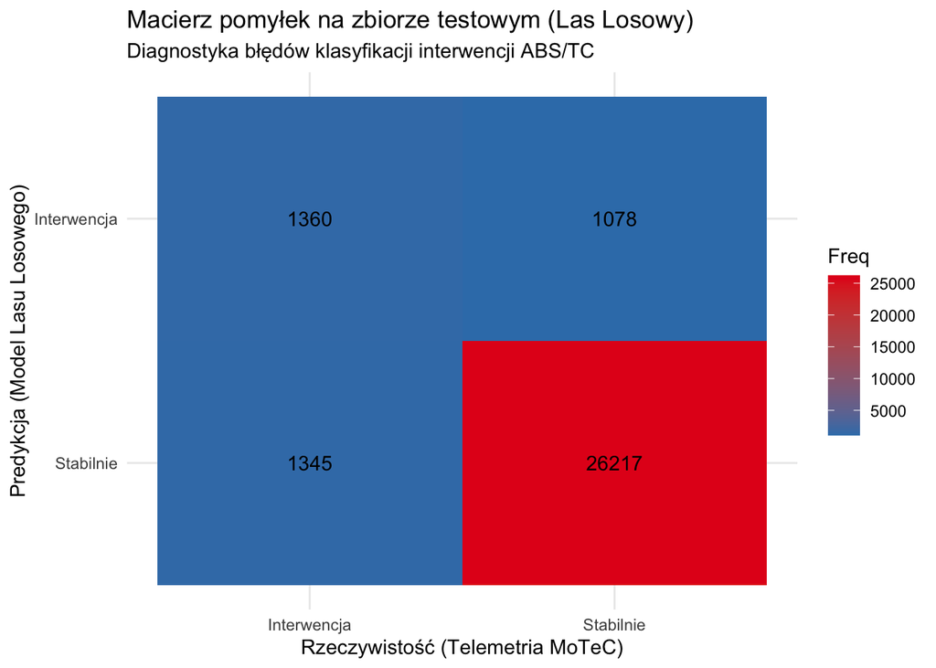

```r
# Wykres mapy ciepła dla macierzy pomyłek
autoplot(cm, type = "heatmap") +
  scale_fill_gradient(low = "#377EB8", high = "#E41A1C") +
  labs(
    title = "Macierz pomyłek na zbiorze testowym (Las Losowy)",
    subtitle = "Diagnostyka błędów klasyfikacji interwencji ABS/TC",
    x = "Rzeczywistość (Telemetria MoTeC)",
    y = "Predykcja (Model Lasu Losowego)"
  ) +
  theme_minimal()
```

W sportach motorowych priorytetem jest bezpieczeństwo i maksymalna czułość – system wczesnego ostrzegania woli wygenerować kilka bezpiecznych alarmów prewencyjnych (FP), niż przeoczyć realny moment zablokowania kół.

## 9. Globalna wyjaśnialność decyzji modelu (XAI - Variable Importance)

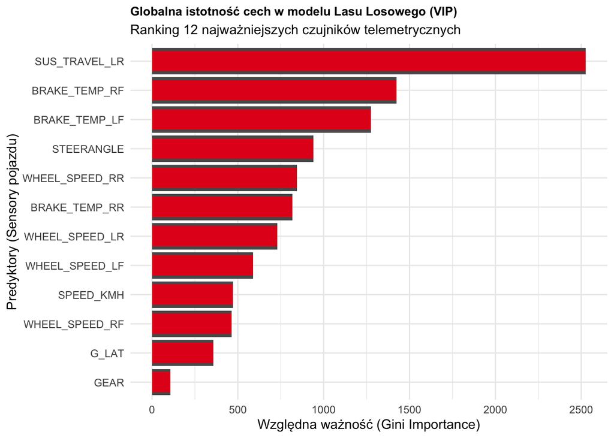

```r
# --- GLOBALNA WYJAŚNIALNOŚĆ MODELU (VARIABLE IMPORTANCE PLOT - VIP) ---
# Ekstrakcja dopasowanego modelu z obiektu last_fit
fitted_workflow <- final_rf_results %>% extract_workflow()
fitted_model <- final_rf_results %>% extract_fit_parsnip()

# Generowanie wykresu istotności cech za pomocą pakietu vip
vip_plot <- vip(fitted_model, num_features = 12, geom = "col") +
  geom_col(fill = "#E41A1C", width = 0.7) +
  theme_minimal() +
  labs(
    title = "Globalna istotność cech w modelu Lasu Losowego (VIP)",
    subtitle = "Ranking 12 najważniejszych czujników telemetrycznych",
    x = "Predyktory (Sensory pojazdu)",
    y = "Względna ważność (Gini Importance)"
  ) +
  theme(plot.title = element_text(face = "bold", size = 10))

print(vip_plot)
```

Wykres ważności cech (*Gini Importance*) dla odchudzonego modelu zredukowanego do 12 kluczowych predyktorów ujawnia fizyczną strukturę podejmowania decyzji przez algorytm Lasu Losowego:

## 10. Wdrożenie modelu

```r
# EKSTRAKCJA I ZAPIS MODELU (DEPLOYMENT READY)
# Wyciągamy w pełni dopasowany workflow (zawiera przepis normalizacji i model Lasu Losowego)
wytrenowany<- extract_workflow(final_rf_results)

# Zapisujemy obiekt do pliku
saveRDS(wytrenowany, "mclaren_rf_telemetry_model.rds")
cat("Model został pomyślnie zserializowany i zapisany jako 'mclaren_rf_telemetry_model.rds'\n\n")
```

```
## Model został pomyślnie zserializowany i zapisany jako 'mclaren_rf_telemetry_model.rds'
```

```r
# LOSOWANIE SCENARIUSZY BEZPOŚREDNIO Z ORYGINALNYCH KLAS ZBIORU TESTOWEGO
set.seed(1234) # Ustalamy punkt startowy losowania dla powtarzalności raportu

# Scenariusz A: Losujemy 1 surowy wiersz, w którym systemy fizycznie NIE interweniowały
scenariusz_stabilny <- test_data %>%
  filter(INTERWENCJA == "Stabilnie") %>%
  slice_sample(n = 1)

# Scenariusz B: Losujemy 1 surowy wiersz, w którym systemy fizycznie AKTYWNIE interweniowały
scenariusz_krytyczny <- test_data %>%
  filter(INTERWENCJA == "Interwencja") %>%
  slice_sample(n = 1)

# FUNKCJA SYMULACJI KOMPUTERA POKŁADOWEGO (INFERENCE ENGINE)
symuluj <- function(surowe_dane_z_czujnika, nazwa_zdarzenia) {

  # automatyczne zaaplikowanie step_normalize() z treningu
  klasa_predykowana <- predict(wytrenowany, new_data = surowe_dane_z_czujnika) %>% pull(.pred_class)
  prawdopodobienstwa <- predict(wytrenowany, new_data = surowe_dane_z_czujnika, type = "prob")

  prob_interwencja <- prawdopodobienstwa$.pred_Interwencja * 100

  # Wizualizacja logu systemowego w konsoli
  cat("=================================================================\n")
  cat(" METRIC STREAMING TELEMETRY SIMULATOR | ", nazwa_zdarzenia, "\n")
  cat("=================================================================\n")
  cat(sprintf(" [SENSOR] Prędkość pojazdu:      %.1f km/h\n", surowe_dane_z_czujnika$SPEED_KMH))
  cat(sprintf(" [SENSOR] Pozycja pedału gazu:   %.1f %%\n", surowe_dane_z_czujnika$THROTTLE))
  cat(sprintf(" [SENSOR] Nacisk na hamulec:     %.1f %%\n", surowe_dane_z_czujnika$BRAKE))
  cat(sprintf(" [SENSOR] Kąt skrętu kierownicy: %.1f deg\n", surowe_dane_z_czujnika$STEERANGLE))
  cat(sprintf(" [SENSOR] Skok zawieszenia LR:   %.1f mm\n", surowe_dane_z_czujnika$SUS_TRAVEL_LR))
  cat("-----------------------------------------------------------------\n")
  cat(sprintf(" [MODEL] Prawd. utraty przyczepności:  %.2f %%\n", prob_interwencja))
  cat(sprintf(" [MODEL] Rekomendowany status:        %s\n", as.character(klasa_predykowana)))

  if(klasa_predykowana == "Interwencja") {
    cat(" [STATUS ALERT] >>> ABS/TC AKTYWNE <<<\n")
  } else {
    cat(" [STATUS OK]    >>> BRAK ZAGROŻENIA <<<\n")
  }
  cat("=================================================================\n\n")
}

# 4. URUCHOMIENIE SYMULACJI PREDYKCJI
symuluj(scenariusz_stabilny, "LOSOWY REKORD - JAZDA STABILNA")
```

```
## =================================================================
##  METRIC STREAMING TELEMETRY SIMULATOR |  LOSOWY REKORD - JAZDA STABILNA
## =================================================================
##  [SENSOR] Prędkość pojazdu:      154.8 km/h
##  [SENSOR] Kąt skrętu kierownicy: -33.0 deg
##  [SENSOR] Skok zawieszenia LR:   50.0 mm
## -----------------------------------------------------------------
##  [MODEL] Prawd. utraty przyczepności:  0.00 %
##  [MODEL] Rekomendowany status:        Stabilnie
##  [STATUS OK]    >>> BRAK ZAGROŻENIA <<<
## =================================================================
```

```r
symuluj(scenariusz_krytyczny, "LOSOWY REKORD - AKTWYACJA SYSTEMU")
```

```
## =================================================================
##  METRIC STREAMING TELEMETRY SIMULATOR |  LOSOWY REKORD - AKTWYACJA SYSTEMU
## =================================================================
##  [SENSOR] Prędkość pojazdu:      144.0 km/h
##  [SENSOR] Kąt skrętu kierownicy: 14.0 deg
##  [SENSOR] Skok zawieszenia LR:   18.0 mm
## -----------------------------------------------------------------
##  [MODEL] Prawd. utraty przyczepności:  58.00 %
##  [MODEL] Rekomendowany status:        Interwencja
##  [STATUS ALERT] >>> ABS/TC AKTYWNE <<<
## =================================================================
```

## 11. Wnioski i podsumowanie inżynierskie

Niniejszy projekt z powodzeniem zrealizował cel polegający na zaprojektowaniu, optymalizacji i weryfikacji kompletnego potoku uczenia maszynowego (machine learning pipeline) do automatycznej detekcji stanów granicznych przyczepności pojazdu klasy GT3 na podstawie surowych danych telemetrycznych z certyfikowanego symulatora Assetto Corsa Competizione.

### 11.1. Główne wnioski inżynierskie i metodologiczne

**Likwidacja błędu optymistycznego (Data Leakage):** Pierwotne wyniki bliskie ideałowi ($ROC\ AUC = 0.998$) wynikały z wycieku danych przez bliskie sąsiedztwo czasowe klatek oddalonych o 5 ms. Zastosowanie podziału ciągłego bloku czasu urealniło metryki. Ostateczny wynik **ROC AUC = 0.921** na całkowicie obcym horyzoncie czasowym udowadnia, że model skutecznie zgeneralizował wiedzę i nie uległ przeuczeniu.

W celu pełnego przystosowania systemu do warunków produkcyjnych (na torze), rekomendowanym kolejnym krokiem jest **kalibracja progu decyzyjnego**. Obniżenie matematycznego progu odcięcia z domyślnego poziomu $0.5$ do wartości z przedziału $0.30 - 0.35$ pozwoli na drastyczne zredukowanie błędów typu *False Negative* i podniesienie operacyjnej czułości systemu. W efekcie inżynier wyścigowy oraz kierowca zyskają bezcenny system prewencyjny, informujący o ryzyku uślizgu na ułamki sekund przed reakcją fabrycznych systemów pojazdu

### 11.2. Potencjał i kierunki rozwoju

Zbudowane rozwiązanie posiada realny potencjał aplikacyjny i może zostać wdrożone w systemach telemetrycznych zespołów simracingowych lub inżynierii pojazdów prototypowych.

Dalszy rozwój projektu mógłby obejmować:

- Rozszerzenie bazy treningowej o dane pochodzące z jazdy w zróżnicowanych warunkach atmosferycznych (tor mokry, zmienne temperatury otoczenia), co pozwoliłoby na zbadanie wpływu termodynamiki opon.
- Integralność w symulacjach w czasie rzeczywistym w trakcie sesji przejazdowej.

Podsumowując, projekt udowadnia, że nowoczesne techniki eksploracji danych stanowi potężne narzędzie inżynieryjne, zdolne do automatyzacji pracy inżyniera wyścigowego i optymalizacji bezpieczeństwa oraz osiągów pojazdu na granicy przyczepności opon.

## Literatura i źródła danych

- https://dariuszmajerek.github.io/ML_and_DM/
- https://dax44.github.io/ModelsValidation/
- R. Jain, M. Rohit, A. Kumar, A. Bakliwal, A. Makwana, M. Rahevar. *Prediction of Telemetry Data using Machine Learning Techniques*. 2022, DOI: https://doi.org/10.17577/IJERTV11IS090048.
- J. Segers, *Analysis Techniques for Racecar Data Acquisition, Second Edition*, SAE International, Warrendale 2014, DOI: https://doi.org/10.4271/R-408.